# GÖRSEL ANALİZ

###### Veri setinin görselleştirilmesi

```python
import warnings

warnings.filterwarnings('ignore')
```

```python
import numpy as np
import pandas as pd
import seaborn as sns
import matplotlib.pyplot as plt

%matplotlib inline
```

```python
df = pd.read_csv('data/dream.csv')
```

- Oluşturduğumuz veri setini görselleştirerek veriler arasındaki ilişkileri inceledik.

### İl / İlçe Dağılımı

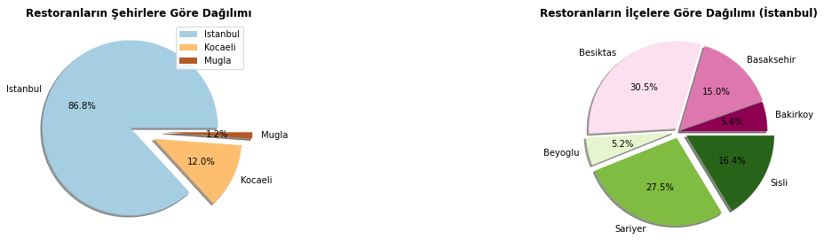

```python
df_city = df.groupby('restaurant_city').size()
df_district = df[~df.restaurant_district.isin(['Bodrum', 'Dilovasi'])].groupby('restaurant_district').size()

plt.figure(1, figsize=(20, 10))

ax1 = plt.subplot(221)
df_city.plot(kind='pie', subplots=True, autopct='%1.1f%%', shadow=True, ax=ax1,
             explode=[.1, .2, .3],
             cmap=plt.cm.get_cmap('Paired'))
plt.legend(loc="upper right", fontsize=10)
plt.ylabel('')
plt.title('Restoranların Şehirlere Göre Dağılımı', weight='bold', size=12)

ax2 = plt.subplot(222)
df_district.plot(kind='pie', subplots=True, autopct='%1.1f%%', shadow=True, ax=ax2,
                 explode=[.01, .02, .04, .06, .08, .1],
                 cmap=plt.cm.get_cmap('PiYG'))
plt.ylabel('')
plt.title('Restoranların İlçelere Göre Dağılımı (İstanbul)', weight='bold', size=12)

plt.show()
```

### Restoran Kapasiteleri

- Restoranların iç ve dış mekanda ağırlayabilecekleri müşteri sayısı kapasitesi değişiklik gösteriyor.
- Butik restoranların diğer restoran tiplerine kıyasla kapasitelerinin daha yüksek olduğu görülüyor.

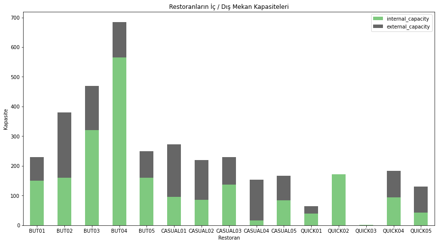

```python
df_capacity = df[['restaurant_name', 'internal_capacity', 'external_capacity']].groupby('restaurant_name', as_index=False).mean()

plt.figure(2, figsize=(15, 8))

ax3 = plt.subplot(111)
df_capacity.plot(kind='bar', stacked=True, ax=ax3, cmap=plt.cm.get_cmap('Accent'))
ax3.set_xticklabels(df_capacity.restaurant_name.unique(), rotation=0)
plt.legend(loc="upper right", fontsize=10)
plt.xlabel('Restoran')
plt.ylabel('Kapasite')
plt.title('Restoranların İç / Dış Mekan Kapasiteleri')

plt.show()
```

### Korelasyon

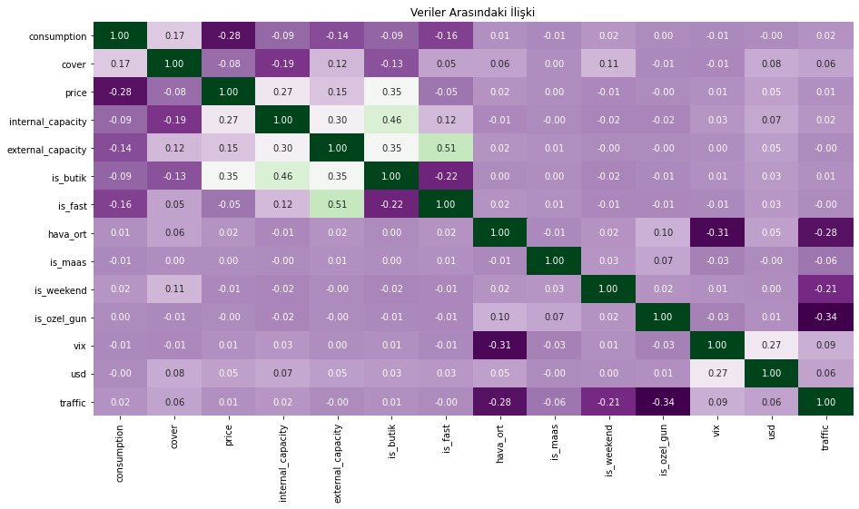

```python
df_corr = df[['consumption', 'cover', 'price', 'internal_capacity', 'external_capacity', 'is_butik', 'is_fast',
              'hava_ort', 'is_maas', 'is_weekend', 'is_ozel_gun', 'vix', 'usd', 'traffic']].corr()

plt.figure(3, figsize=(15, 8))

ax4 = plt.subplot(111)
sns.heatmap(df_corr, annot=True, fmt='.2f', cbar=False, ax=ax4, cmap=plt.get_cmap('PRGn'))
ax4.set_yticklabels(ax4.get_yticklabels(), rotation='horizontal')
plt.title('Veriler Arasındaki İlişki')

plt.show()
```

- Volatilite endeksi (vix), dolar kuru (usd) ile pozitif bir korelasyon gösteriyor. Dolar kuru ise müşteri sayısı (cover) ile kısmen olumlu bir ilişkiye sahip denilebilir.

### Özel Günlerde Trafik

- Korelasyon tablosuna göre bayram, resmi tatil gibi özel günler (is_ozel_gun) ile trafik yoğunluğu (traffic) arasında ters orantı bulunuyor.
- Özel günlerde trafik yoğunluğu azalıyor.

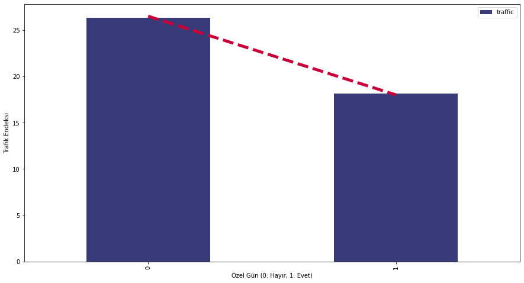

```python
df_holiday = df[['is_ozel_gun', 'traffic']].groupby('is_ozel_gun', as_index=False).mean()

plt.figure(4, figsize=(15, 8))

ax5 = plt.subplot(111)
df_holiday.plot(kind='bar', x='is_ozel_gun', y='traffic', ax=ax5, cmap=plt.get_cmap('tab20b'))
plt.plot([0, 1], [26.5, 18], color='#C70039', linestyle='--', linewidth=5)
plt.xlabel('Özel Gün (0: Hayır, 1: Evet)')
plt.ylabel('Trafik Endeksi')
plt.xticks(df_holiday.is_ozel_gun.unique())

plt.show()
```

### Hava Durumuna Göre Trafik

- Özel günlerin yanı sıra, hava durumunun (hava_ort) trafik endeksi ile olumsuz bir ilişkisi olduğu görünüyor.
- Hava sıcaklığı arttıkça trafik yoğunluğu azalıyor.

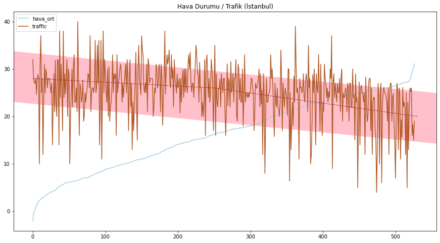

```python
df_ist = df[df.restaurant_city == 'Istanbul']
df_weather = df_ist[['hava_ort', 'traffic']].groupby('hava_ort', as_index=False).mean()

plt.figure(5, figsize=(15, 8))

ax6 = plt.subplot(111)
plt.plot([0, 530], [28, 20], color='pink', linestyle='-', linewidth=100)
df_weather.plot(ax=ax6, cmap=plt.cm.get_cmap('Paired'))
plt.plot([0, 250], [28, 26], color='brown', linestyle='--', linewidth=1)
plt.plot([250, 530], [26, 20], color='brown', linestyle='--', linewidth=1)
plt.legend(loc="upper left", fontsize=10)
plt.title('Hava Durumu / Trafik (İstanbul)')

plt.show()
```

### Trafiğin Müşteri Sayısı İle İlişkisi

- Korelasyon tablosuna göre trafik endeksi ile müşteri sayısı (cover) arsında kısmen olumlu bir ilişki bulunuyor.
- Aşağıdaki tablo incelendiğinde, trafiğin daha yoğun olduğu günlerde müşteri sayısının yüksek olması dikkat çekiyor.

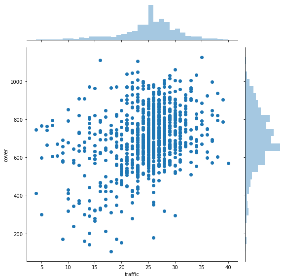

```python
df_traffic = df_ist[['date', 'traffic', 'cover']].groupby(['date'], as_index=False).mean()

sns.jointplot(x='traffic', y='cover', data=df_traffic, height=8)

plt.show()
```

### Müşteri Sayısı Ve Tüketim

- Müşteri sayısı ile restoranlardaki tüketim (consumption) verileri arasında pozitif korelasyon bulunuyor.
- Müşteri sayısındaki artış, tüketim miktarını arttırıyor.

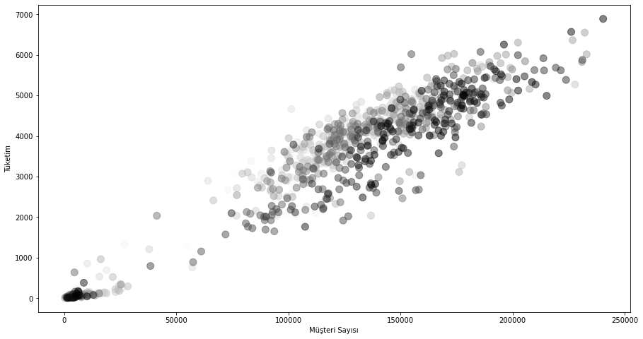

```python
df_cover = df[['date', 'cover', 'consumption']].groupby(['date'], as_index=False).sum()


plt.figure(6, figsize=(15, 8))

ax7 = plt.subplot(111)
df_cover.plot(kind='scatter', x='cover', y='consumption', ax=ax7, s=100, alpha=0.5, c=np.arange(df_cover.shape[0]))
plt.xlabel('Müşteri Sayısı')
plt.ylabel('Tüketim')

plt.show()
```

### Fiyatların Tüketime Etkisi

- Restoranlardaki tüketim miktarı, fiyatlar (price) ile zıt yönde hareket ediyor.
- Fiyatlardaki artışlar, restoranlara tüketim miktarlarında düşüş olarak yansıyor.

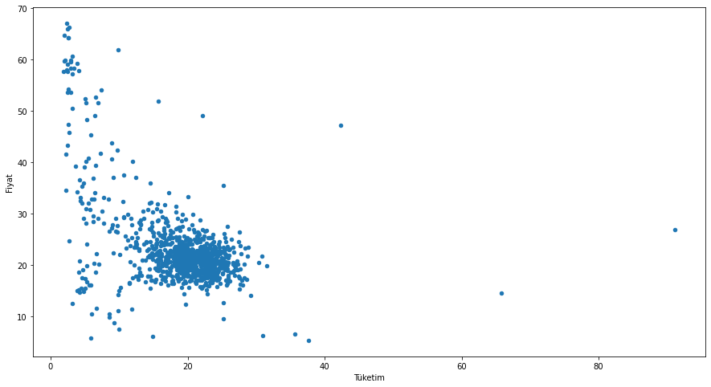

```python
df_consumption = df[['date', 'consumption', 'price']].groupby(['date'], as_index=False).mean()

plt.figure(7, figsize=(15, 8))

ax8 = plt.subplot(111)
df_consumption.plot(kind='scatter', x='consumption', y='price', ax=ax8)
plt.xlabel('Tüketim')
plt.ylabel('Fiyat')

plt.show()
```